# The Neuron Model: Fitzhugh-Nagumo Equations

The final goal of the class is to discuss the Fitzhugh-Nagumo (FN) equations, which are a (simplified) model of a neuron. Since we have had a lot of cancellations, I won’t be able to explain each peice of the model as in depth, but I still will try to give you the feeling of the model.

## Voltage

The first quantity we track is the voltage $V$ on the neuron’s membrane. (The book uses lowercase $v$.) When people speak of “neuron spikes” they are talking about the voltage level in the membrane peaking. The key physics fact you need to understand this is that voltage is electric energy.

## Recovery Mechanism

The second quantity we will track in the model is a recovery variable $R$. (The book uses $w$ instead of $R$.) The idea is this: we are going to model the potential in the cell, but at the same time we will introduce a *recovery variable* $R$, which can be thought of as the mechanism that brings the neuron back down from high peaks.

## The model (without external current)

This is the kind of model we want. I will explain the main features.

$$\begin{align*}
\frac{dV}{dt} = f(V) - R\\
\frac{dR}{dt} = a V - b R.
\end{align*}$$

Just like modeling populations, when we model these quantities, we put in terms that should influence the rates of change of these variables. So what I’m saying with the first equation is the rate of change of voltage depends on

- some function of voltage, $f(V)$, that models how we think voltage should work. Since this term is “voltage influencing itself,” it can be helpful to think of $f(V)$ as a “feedback” function.
- the recovery variable $R$ acts to supress the voltage, hence the $-R$ term.

The second equation is justified by two ideas:

- high voltage should turn on the recovery.
- if the recovery is large, the recovery mechanism wants to turn back off so voltage can grow again (if it needs to).

The parameters depend on the cell at hand, as well as the biochemistry of the situation. In order to keep things simple, I won’t delve into it. If you are interested, there are ways to make the model more complex using the biochemistry.

The mechanisms in the cell I will leave to you to read about (see chapter 5.8 in the textbook). It involves sodium and potassium flow into and out of the cell, and the chemistry determines how the cell deals with voltage spikes. Since we are modeling with mathematics, we are allowed to hide the details of the chemistry in our model. Really, the recovery variable depends on the chemistry. However, mathematical modeling is about starting simply and then improving the model. So, I will discuss the model above, and more detailed analysis of the chemistry would lead you to more complex models for $R$.

### Format of $f(V)$

We now ask ourselves, how do we want to model the voltage’s influence on itself? We want our model to include three things:

- A **resting** voltage level
- A **threshold** voltage level that the neuron activates once reached
- A maximum potential that represents a **fully activated** neuron.

So, on a number line for voltage, we expect three special locations. $V=0$ will correspond with an “off” or “resting” neuron. A voltage $V=1$ will mean “fully activated”.

The third special location will be a “critical threshold” for activation, which we designate a parameter $c$, so $V=c$ is the cutoff. This is kind of like the cutoff voltage we had in the heart model last quarter. Now, we don’t ever want the neuron to get stuck at the cutoff; we rather it either go to rest ($V=0$) or turn on ($V=1$). So, we should make sure the phase line comes out so that $V=c$ is unstable.

If we pretend that the recovery mechanism is removed for a moment, then the equation
$$\frac{dV}{dt} = f(V)$$
is just an autonomous differential equation, so a phase line can help us conceive of $f(V)$. It should have three equilibria at $V=0$, $V=c$, and $V=1$. The easiest way to make this happen is the function
$$f(V) = - V\cdot (V-c) \cdot (V-1).$$
In using the style of a factored polynomial, we can build in these equilibria by hand! The minus sign out front is also crucial: it ensures that $0$ and $1$ are stable (like we expect a neuron to be), while $c$ is unstable.

By the way, you can think of the parameter $c$ as the willingness for the neuron to activate. A small $c$ means that it is easy for the neuron to activate, while a larger value (closer to 1) means that the neuron has trouble activating. (You might think of trying to model some kind of Alzheimers-affected neurons with this parameter.)

Finally, we have the Fitzhugh-Nagumo equations:
$$\begin{align*}
\frac{dV}{dt} &= - V(V-c)(V-1) - R\\
\frac{dR}{dt} &= aV - bR.
\end{align*}$$

And that’s the modeling aspect! You will explore this model in the homework this week.

## With External Current

One slight modification to this is if you *stimulate* the neuron with an external current. Remember from physics, $V= IR$. If we pretend that $R= 1$ ohm (or just rescale voltage), we can add in a term to the first equation that incorporates applying an external current, and we now get what I might call the “Fitzhugh-Nagumo equations with current:”
$$\begin{align*}
\frac{dV}{dt} &= - V(V-c)(V-1) - R + I\\
\frac{dR}{dt} &= aV - bR.
\end{align*}$$
Now of course I haven’t said what $I$ is. It can be constant; it can depend on time; and it could depend on a whole lot of other things! The point is we are modeling, so for now we can just assume $I$ is a constant and see what it entails. More sophisticated models would have more to say about what $I$ is (and how it shows up in the equations). Again, I will let you explore the model in your homework, but it leads to some cool ideas! (Can you model a brain?)

Nothing new has been added mathematically here. This is just another cool model that you can choose to spend time diving into and exploring.

## Example: without current.

Analyze the behaviour of the neuron through the following trajectory. Explain what happens as time goes forward.

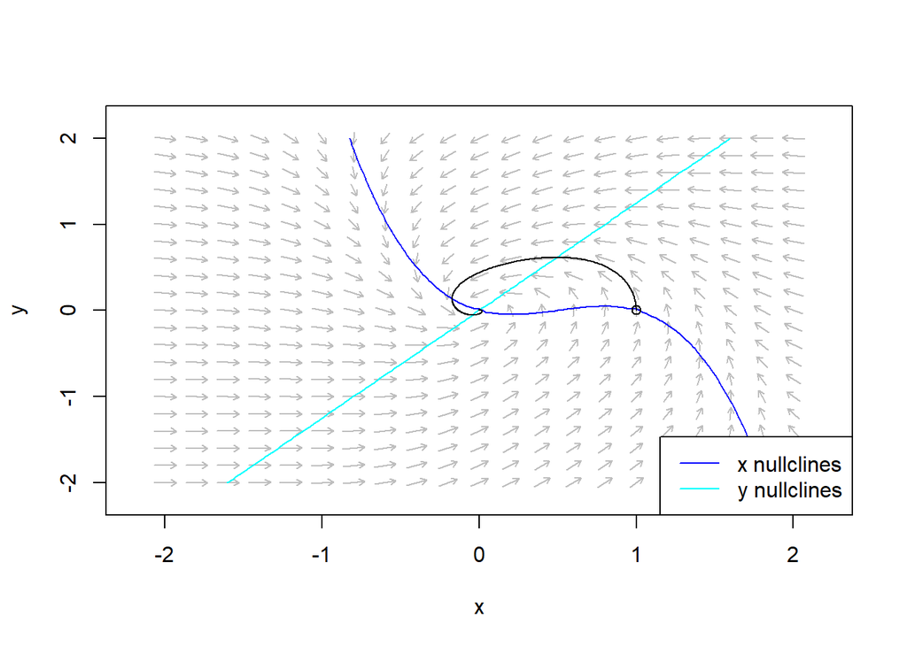

In this case, the neuron begins in an “on” state since $V=1$ is the starting value. (Remember, the horizontal variable is voltage right now). Then, as time goes on, the recovery mechanism starts to turn on, which has the effect of decreasing the neuron’s voltage level (and hence why the trjectory moves up and left). Once the voltage gets lower and lower, the recovery mechanism slowly shuts off, allowing the neuron to go back to rest.

# Questions I may ask you

## Describe the behaviour of a neuron.

1. With the picture below, describe the neuron’s activity. Does there appear to be an applied current?

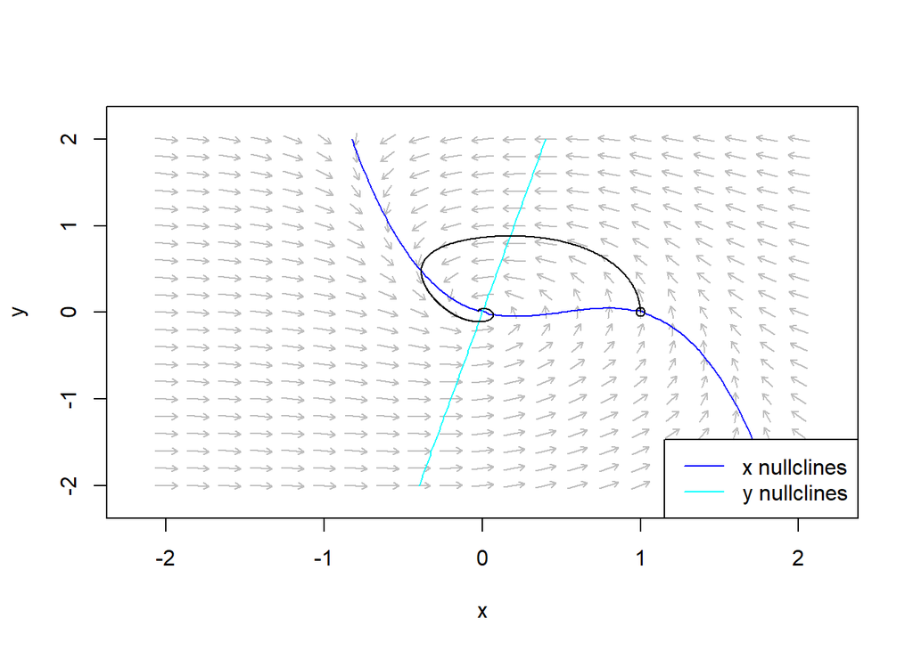

2. With the picture below, describe the neuron’s activity. Does there appear to be an applied current here?

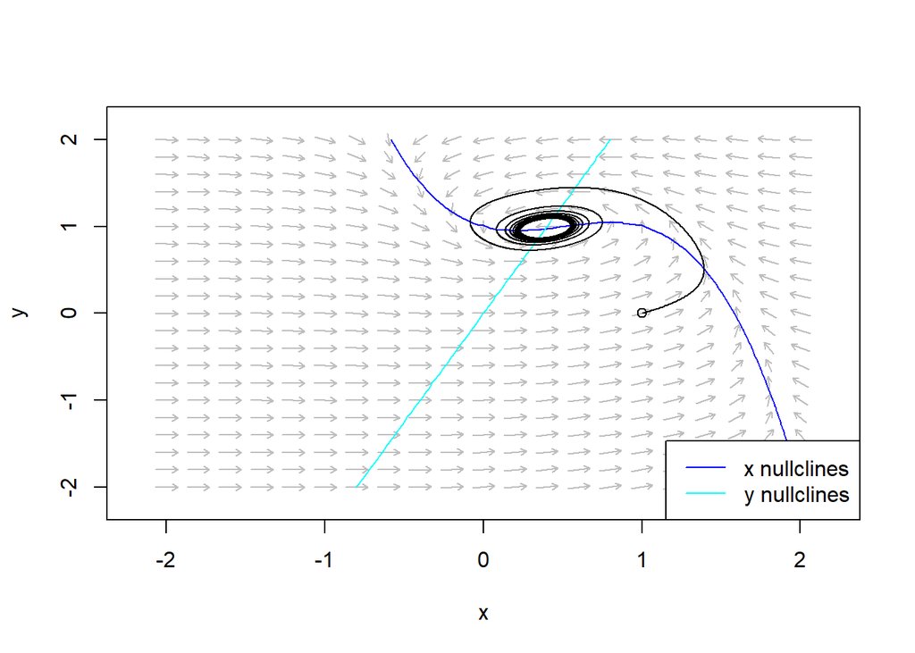

# Numerical solutions

Sometimes you see crazy things happening with trajectories; maybe they seem to get “fatter” and spiral, sometimes they turn sharp corners, etc. The reason this happens is because the computers use Euler’s method to generate curves.

As you know by now, Euler’s method is based on successive approximations; each time step you use the differential equations to produce a slope, which you use to predict new values from old ones. Since you approximate by tangent lines, a slight amount of error gets introduced with each time step. Over time, this error can compound over many iterations. This means that the solutions (trajectories) you get might lose accuracy over time!

The point is that you should be aware of numerical limits of computers. There can be numerical oddities that come out! To get around this, people have developed methods that try to decrease the error in Euler’s method. They produce more “hip” algorithms; one famous one is called **Runge-Kutta**, pronounced like “Rung-uh cut-uh.” There are variations on Runge-Kutta, the most prominent being **Runge-Kutta 4**, abbreviated to *RK4*. (The gist is, in one time step you average the slopes over four subintervals, so you get a better prediction in the end of each step of Euler’s method). If you are curious, a google search with any of these key words will give you more to read.

# Huxley-Hodgkin Equations

Another important side note: the FH equations are a simplified version of a system of **four** equations, known as the Huxley-Hodgkin equations. These were “DE of the Day” a few weeks ago!